# AI for Disaster Response: Improving Emergency Management During Cyclones

Juber

4/5/2020

## EDA and Baseline models Using Bayesian Regression

```r
# Load packages
library(dplyr)
```

```r
library(ggplot2)
library(e1071)
# Load and inspect the data
df=read.csv('/Users/Juber/Desktop/Master_1068.csv')
head(df)
```

```
##             SID    NAME ISO YEAR_MIN              X BASIN SUBBASIN NATURE
## 1 1949163N07145   DELLA JPN     1949   DELLAJPN1949    WP       WP     TS
## 2 1950241N23140    JANE JPN     1950    JANEJPN1950    WP       WP     ET
## 3 1951224N12316 CHARLIE JAM     1951 CHARLIEJAM1951   NAm      NAm     TS
## 4 1951337N09150     AMY PHL     1951     AMYPHL1951    WP       WP     TS
## 5 1952180N05144    EMMA PHL     1952    EMMAPHL1952    WP       WP     TS
## 6 1952287N09148    TRIX PHL     1952    TRIXPHL1952    WP       WP     TS
##   TRACK_TYPE
## 1       main
## 2       main
## 3       main
## 4       main
## 5       main
## 6       main
##                                                                                                                                                                                                                                                                                                          …
```

[output cut: 41 more lines]

```r
str(df)
```

```
## 'data.frame':    1068 obs. of  29 variables:
##  $ SID                                  : Factor w/ 796 levels "1949163N07145",..: 1 2 3 4 5 6 7 8 9 10 ...
##  $ NAME                                 : Factor w/ 579 levels "ABE","ADEL","AERE",..: 112 281 81 18 144 537 559 234 241 213 ...
##  $ ISO                                  : Factor w/ 63 levels "AUS","BGD","BHS",..: 23 23 22 39 39 39 39 18 29 16 ...
##  $ YEAR_MIN                             : int  1949 1950 1951 1951 1952 1952 1952 1954 1955 1957 ...
##  $ X                                    : Factor w/ 1068 levels "ABECHN1990","ABECHN1993",..: 200 521 150 36 269 990 1035 431 438 376 ...
##  $ BASIN                                : Factor w/ 6 levels "EP","NAm","NI",..: 6 6 2 6 6 6 6 2 2 6 ...
##  $ SUBBASIN                             : Factor w/ 13 levels "AS","BB","CP",..: 13 13 9 13 13 13 13 9 9 13 ...
##  $ NATURE                               : Factor w/ 6 levels "DS","ET","MX",..: 6 2 6 6 6 6 6 6 6 6 ...
##  $ TRACK_TYPE                           : Factor w/ 3 levels "main","PROVISIONAL",..: 1 1 1 1 1 1 1 1 1 1 ...
##  $ ISO_TIME                             : Factor w/ 1068 levels "['1949-06-21 03:00:00', '1949-06-22 03:00:00', '1949-06-22 06:00:00', '1949-06-22 09:00:00', '1949-06-22 12:00:"| __truncated__,..: 1 2 3 4 5 6 7 8 9 10 ...
##  $ COORDS                               : Factor w/ 1068 levels "[[-10.1, 162.9], [-10.15, 162.85], [-10.2, 162.8], [-10.25, 162.75], [-10.3, 162.7], [-10.35, 162.65], [-10.4, "| __truncated__,..: 1021 943 434 205 1065 261 201 411 576 701 ...
##  $ TOTAL_HRS                            : int  0 6 15 15 3 21 12 6 0 21 ...
##  $ DAY_HRS                              : int  0 0 0 0 2 0 0 0 0 0 ...
##  $ NIGHT_HRS                            : int  0 6 15 15 1 21 12 6 0 21 ...
##  $ USA_SSHS                             : int  0 -1 1 2 1 3 2 3 3 -1 ...
##  $ WIND_CALC_MEAN..v_land_kn.to.be.used.: num  39.1 76.4 88.5 84.5 83.9 ...
##  $ PRES_CALC_MEAN                       : num  1000 975 974 980 981 ...
##  $ STORM_SPD_MEAN                       : num  19 23 15.5 3 10.8 ...
##  $ STORM_DR_MEAN                        : num  91.4 37.7 283.5 161.6 291.4 ...
##  $ V_LAND_KN                            : num  99.8 99.8 132.4 119.2 110.7 ...
##  $ X34KN_POP                            : int  NA NA 2788659 20464826 NA 43820633 28281376 10396164 8356553 8148473 ...
##  $ X34KN_ASSETS                         : num  NA NA 2.15e+10 1.88e+11 NA ...
##  $ X64KN_POP                            : int  NA NA 2788659 12675908 NA 15600481 7957281 3570247 3436347 0 ...
##  $ X64KN_ASSETS                         : num  NA NA 2.15e+10 1.13e+11 NA ...
##  $ X96KN_POP                            : int  NA NA 2552903 5618193 NA 7144691 3424599 1234448 1092040 0 ...
##  $ X96KN_ASSETS                         : num  NA NA 1.95e+10 4.90e+10 NA ...
##  $ CPI                                  : num  9.33 9.43 10.18 10.18 10.41 ...
##  $ TOTAL_DAMAGE_.000..                  : int  NA NA 56000 NA NA 50000 50000 NA NA NA ...
##  $ Total.Affected.                      : int  194046 642117 20200 60000 103 349 349 250000 11432 111 ...
```

## visualize the distribution of target variable

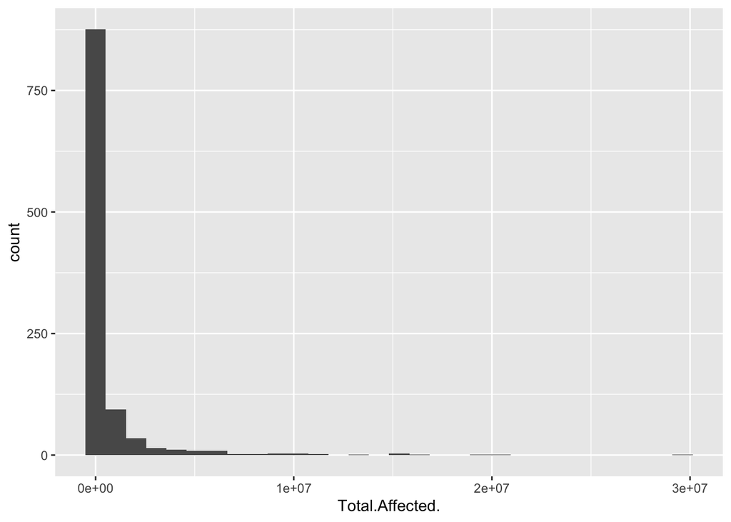

```r
ggplot(df,aes(Total.Affected.))+geom_histogram()
```

```r
# check the skewness value
skewness(df$Total.Affected.)
```

```
## [1] 6.927446
```

### comment : higly skewed

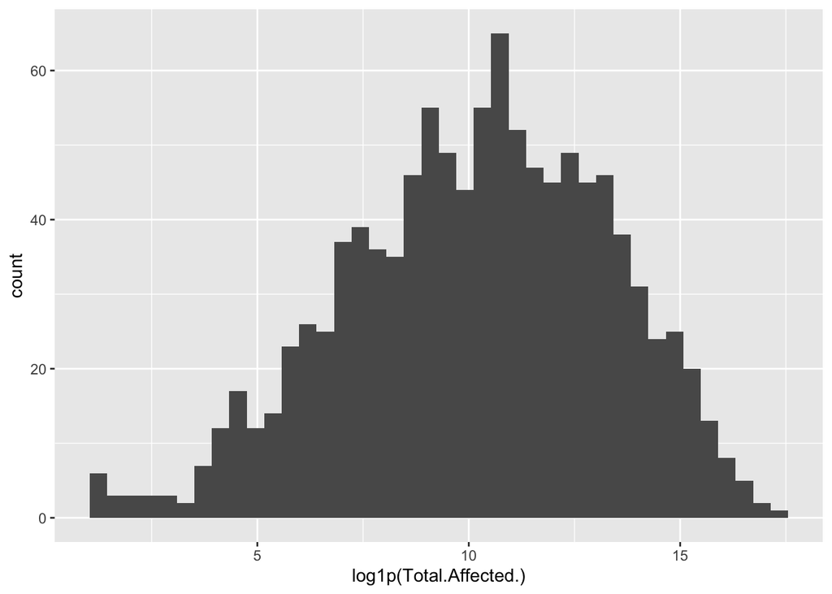

```r
# check the distribution of log-coverted target
ggplot(df,aes(log1p(Total.Affected.)))+geom_histogram(bins=40)
```

## comment: log conversion reduced the skewness

```r
#select the numeric features
numeric_features<-df%>%select_if(is.numeric)
#cat_features<-df%>%select_if(negate(is.numeric))
anyNA(numeric_features)
```

```
## [1] TRUE
```

```r
#anyNA(cat_features)
print(names(which(sapply(numeric_features, anyNA))))
```

```
## [1] "WIND_CALC_MEAN..v_land_kn.to.be.used."
## [2] "X34KN_POP"
## [3] "X34KN_ASSETS"
## [4] "X64KN_POP"
## [5] "X64KN_ASSETS"
## [6] "X96KN_POP"
## [7] "X96KN_ASSETS"
## [8] "TOTAL_DAMAGE_.000.."
```

# deal with missing data

```r
library(DMwR)
knnOutput <- knnImputation(df[, !names(df) %in% "TOTAL_DAMAGE_.000.."])  # perform knn imputation.
anyNA(knnOutput)
```

```
## [1] FALSE
```

```r
# check the influence of selected categorical predictors- cyclone category in simpson scale
#ggplot(df,aes(y=log1p(Total.Affected.),fill=as_factor(USA_SSHS)))+geom_boxplot()
```

Saffir-Simpson Hurricane Scale information based on the wind speed provided by the US agency wind speed (US agencies provide 1-minute wind speeds) -5 = Unknown [XX] -4 = Post-tropical [EX, ET, PT] -3 = Miscellaneous disturbances [WV, LO, DB, DS, IN, MD] -2 = Subtropical [SS, SD] Tropical systems classified based on wind speeds [TD, TS, HU, TY,, TC, ST, HR] -1 = Tropical depression (W<34) 0 = Tropical storm [34<W<64] 1 = Category 1 [64<=W<83] 2 = Category 2 [83<=W<96] 3 = Category 3 [96<=W<113] 4 = Category 4 [113<=W<137] 5 = Category 5 [W >= 137]

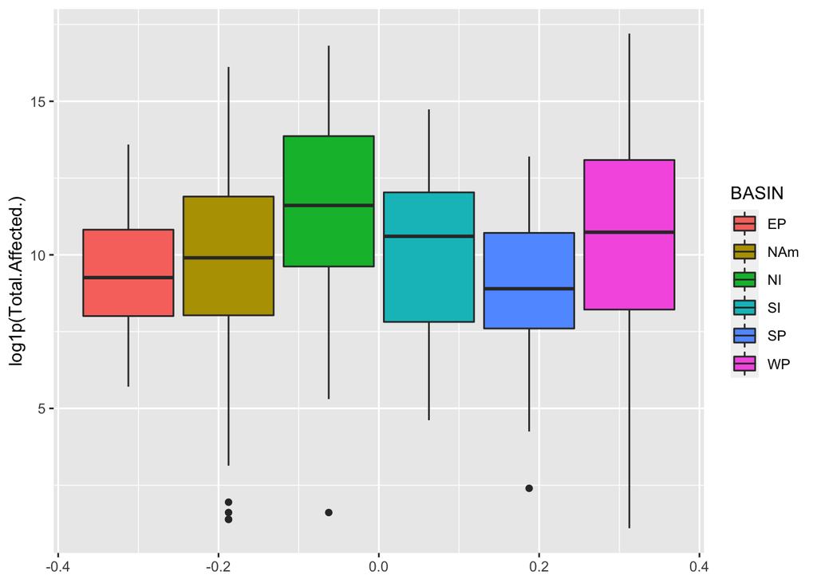

```r
# check the influence of selected categorical predictors- cyclone basin
ggplot(df,aes(y=log1p(Total.Affected.),fill=BASIN))+geom_boxplot()
```

### NI- basin seems slightly more dangerous Basins info: NA - North Atlantic EP - Eastern North Pacific WP - Western North Pacific NI - North Indian SI - South Indian SP - Southern Pacific SA - South Atlantic MM - Missing

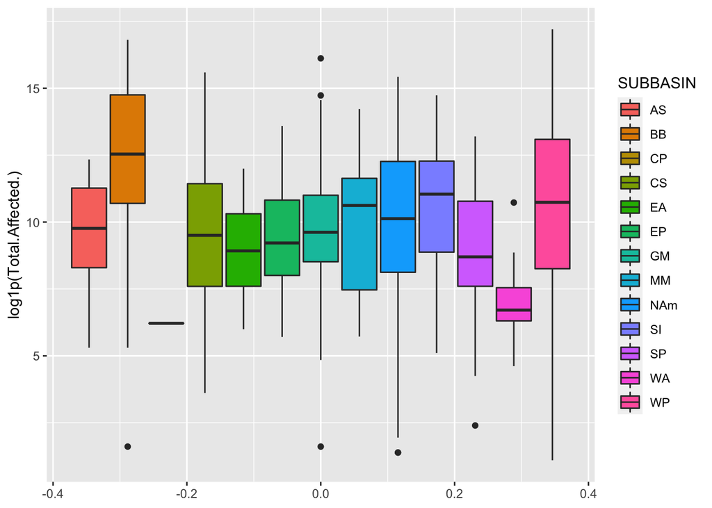

```r
# what about sub-basin?
ggplot(df,aes(y=log1p(Total.Affected.),fill=SUBBASIN))+geom_boxplot()
```

### some of them are different than others MM - missing - no sub basin for this basin (no subbasins provided for WP, SI) CS - Caribbean Sea GM - Gulf of Mexico CP - Central Pacific BB - Bay of Bengal AS - Arabian Sea WA - Western Australia EA - Eastern Australia

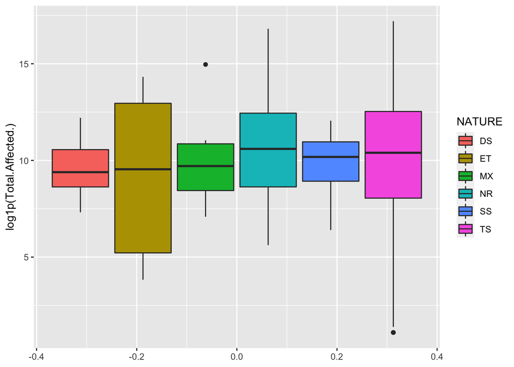

```r
# what about nature?
ggplot(df,aes(y=log1p(Total.Affected.),fill=NATURE))+geom_boxplot()
```

### Does not seem making much difference

```r
# let's first check a linear regression model
lm.model = lm(log1p(Total.Affected.) ~ X96KN_POP+X64KN_POP+X34KN_POP+V_LAND_KN+USA_SSHS+SUBBASIN+STORM_SPD_MEAN+PRES_CALC_MEAN+TOTAL_HRS, data = df)
summary(lm.model)
```

```
##
## Call:
## lm(formula = log1p(Total.Affected.) ~ X96KN_POP + X64KN_POP +
##     X34KN_POP + V_LAND_KN + USA_SSHS + SUBBASIN + STORM_SPD_MEAN +
##     PRES_CALC_MEAN + TOTAL_HRS, data = df)
##
## Residuals:
##     Min      1Q  Median      3Q     Max
## -9.2938 -1.7041  0.4057  2.0639  7.9608
##
## Coefficients:
##                  Estimate Std. Error t value Pr(>|t|)
## (Intercept)     1.044e+01  2.491e+00   4.191 3.08e-05 ***
## X96KN_POP       1.607e-07  5.105e-08   3.149  0.00170 **
## X64KN_POP      -5.974e-08  2.421e-08  -2.468  0.01379 *
## X34KN_POP       4.605e-08  9.179e-09   5.018 6.45e-07 ***
## V_LAND_KN       1.791e-02  4.606e-03   3.888  0.00011 ***
## USA_SSHS       -2.302e-01  7.250e-02  -3.175  0.00155 **
## SUBBASINBB      1.491e+00  1.295e+00   1.152  0.24978
## SUBBASINCP     -2.842e+00  3.796e+00  -0.749  0.45426
## SUBBASINCS      7.420e-01  1.157e+00   0.641  0.52162
## SUBBASINEA     -9.925e-01  1.391e+00  -0.714  0.47565
## SUBBASINEP     -1.779e-03  1.153e+00  -0.002  0.99877
## SUBBASINGM      1.530e-02  1.228e+00   0.012  0.99006
## SUBBASINMM     -3.142e-01  1.428e+00  -0.220  0.82595
## SUBBASINNAm     9.858e-01  1.094e+00   0.901  0.36785
## SUBBASINSI      3.979e-01  1.135e+00   0.351  0.72598
## SUBBASINSP     -9.478e-01  1.203e+00  -0.788  0.43097
## SUBBASINWA     -2.538e+00  1.433e+00  -1.771  0.07693 .
## SUBBASINWP      5.819e-01  1.066e+00   0.546  0.58547
## STORM_SPD_MEAN -1.170e-01  1.813e-02  -6.454 1.89e-10 ***
## PRES_CALC_MEAN -1.703e-03  2.180e-03  -0.781  0.43491
## TOTAL_HRS       2.182e-02  1.456e-02   1.498  0.13453
## ---
## Signif. codes:  0 '***' 0.001 '**' 0.01 '*' 0.05 '.' 0.1 ' ' 1
##
## Residual standard error: 2.969 on 798 degrees of freedom
##   (249 observations deleted due to missingness)
## Multiple R-squared:  0.1553, Adjusted R-squared:  0.1341
## F-statistic: 7.336 on 20 and 798 DF,  p-value: < 2.2e-16
```

```r
# check a tidy-version of the summary
#tidy(lm.model)
```

## update regression model

```r
lm.model2 = lm(log1p(Total.Affected.) ~ X96KN_POP+X64KN_POP+X34KN_POP+V_LAND_KN+USA_SSHS+STORM_SPD_MEAN, data = df)
summary(lm.model2)
```

```
##
## Call:
## lm(formula = log1p(Total.Affected.) ~ X96KN_POP + X64KN_POP +
##     X34KN_POP + V_LAND_KN + USA_SSHS + STORM_SPD_MEAN, data = df)
##
## Residuals:
##     Min      1Q  Median      3Q     Max
## -9.0144 -1.8499  0.3386  2.1418  7.7690
##
## Coefficients:
##                  Estimate Std. Error t value Pr(>|t|)
## (Intercept)     9.638e+00  3.924e-01  24.562  < 2e-16 ***
## X96KN_POP       1.622e-07  5.125e-08   3.165  0.00161 **
## X64KN_POP      -6.201e-08  2.437e-08  -2.545  0.01112 *
## X34KN_POP       5.417e-08  8.610e-09   6.292 5.13e-10 ***
## V_LAND_KN       1.409e-02  4.349e-03   3.240  0.00124 **
## USA_SSHS       -1.503e-01  6.868e-02  -2.189  0.02889 *
## STORM_SPD_MEAN -1.094e-01  1.765e-02  -6.196 9.22e-10 ***
## ---
## Signif. codes:  0 '***' 0.001 '**' 0.01 '*' 0.05 '.' 0.1 ' ' 1
##
## Residual standard error: 2.995 on 812 degrees of freedom
##   (249 observations deleted due to missingness)
## Multiple R-squared:  0.1249, Adjusted R-squared:  0.1185
## F-statistic: 19.32 on 6 and 812 DF,  p-value: < 2.2e-16
```

## Comment : We found some important predictors but the overall model performance is poor

```r
# let's try with imputed dataset
lm.model3 = lm(log1p(Total.Affected.) ~ X96KN_POP+X64KN_POP+X34KN_POP+V_LAND_KN+USA_SSHS+SUBBASIN+STORM_SPD_MEAN+PRES_CALC_MEAN+TOTAL_HRS, data = knnOutput)
summary(lm.model3)
```

```
##
## Call:
## lm(formula = log1p(Total.Affected.) ~ X96KN_POP + X64KN_POP +
##     X34KN_POP + V_LAND_KN + USA_SSHS + SUBBASIN + STORM_SPD_MEAN +
##     PRES_CALC_MEAN + TOTAL_HRS, data = knnOutput)
##
## Residuals:
##     Min      1Q  Median      3Q     Max
## -9.6635 -1.7740  0.2862  2.0993  7.8657
##
## Coefficients:
##                  Estimate Std. Error t value Pr(>|t|)
## (Intercept)     9.903e+00  1.981e+00   4.998 6.80e-07 ***
## X96KN_POP       1.609e-07  4.868e-08   3.306 0.000980 ***
## X64KN_POP      -5.034e-08  2.202e-08  -2.286 0.022454 *
## X34KN_POP       4.092e-08  8.081e-09   5.064 4.85e-07 ***
## V_LAND_KN       1.298e-02  3.519e-03   3.688 0.000237 ***
## USA_SSHS       -1.120e-01  6.041e-02  -1.854 0.064054 .
## SUBBASINBB      2.083e+00  1.026e+00   2.030 0.042581 *
## SUBBASINCP     -2.449e+00  3.481e+00  -0.703 0.481907
## SUBBASINCS     -3.822e-02  9.260e-01  -0.041 0.967087
## SUBBASINEA     -9.079e-01  1.176e+00  -0.772 0.440337
## SUBBASINEP     -5.522e-02  9.396e-01  -0.059 0.953140
## SUBBASINGM      1.543e-01  9.873e-01   0.156 0.875832
## SUBBASINMM     -3.353e-02  1.264e+00  -0.027 0.978835
## SUBBASINNAm     6.969e-01  8.863e-01   0.786 0.431860
## SUBBASINSI      6.727e-01  9.094e-01   0.740 0.459614
## SUBBASINSP     -7.270e-01  9.533e-01  -0.763 0.445856
## SUBBASINWA     -2.406e+00  1.142e+00  -2.107 0.035324 *
## SUBBASINWP      6.195e-01  8.586e-01   0.722 0.470726
## STORM_SPD_MEAN -9.562e-02  1.496e-02  -6.393 2.44e-10 ***
## PRES_CALC_MEAN -1.070e-03  1.732e-03  -0.618 0.536881
## TOTAL_HRS       2.215e-02  1.237e-02   1.790 0.073810 .
## ---
## Signif. codes:  0 '***' 0.001 '**' 0.01 '*' 0.05 '.' 0.1 ' ' 1
##
## Residual standard error: 2.923 on 1047 degrees of freedom
## Multiple R-squared:  0.1352, Adjusted R-squared:  0.1186
## F-statistic: 8.181 on 20 and 1047 DF,  p-value: < 2.2e-16
```

## comment: No improvement with imputation

```r
# let's try with Bayesian regression
library(rstanarm)
# Create the model here
stan_model <- stan_glm(log1p(Total.Affected.) ~ X96KN_POP+X64KN_POP+X34KN_POP+V_LAND_KN+USA_SSHS+SUBBASIN+STORM_SPD_MEAN+PRES_CALC_MEAN+TOTAL_HRS, data = df)
# Produce the summary
summary(stan_model)
```

```
##
## Model Info:
##  function:     stan_glm
##  family:       gaussian [identity]
##  formula:      log1p(Total.Affected.) ~ X96KN_POP + X64KN_POP + X34KN_POP +
##     V_LAND_KN + USA_SSHS + SUBBASIN + STORM_SPD_MEAN + PRES_CALC_MEAN +
##     TOTAL_HRS
##  algorithm:    sampling
##  sample:       4000 (posterior sample size)
##  priors:       see help('prior_summary')
##  observations: 819
##  predictors:   21
##
## Estimates:
##                  mean   sd   10%   50%   90%
## (Intercept)    10.2    2.4  7.2  10.2  13.3
## X96KN_POP       0.0    0.0  0.0   0.0   0.0
## X64KN_POP       0.0    0.0  0.0   0.0   0.0
## X34KN_POP       0.0    0.0  0.0   0.0   0.0
## V_LAND_KN       0.0    0.0  0.0   0.0   0.0
## USA_SSHS       -0.2    0.1 -0.3  -0.2  -0.1
## SUBBASINBB      1.5    1.2  0.0   1.5   3.1
## SUBBASINCP     -2.4    3.4 -6.9  -2.4   2.0
## SUBBASINCS      0.8    1.1 -0.6   0.8   2.1
## SUBBASINEA     -0.9    1.3 -2.6  -0.9   0.7
## SUBBASINEP      0.0    1.0 -1.3   0.0   1.4
## SUBBASINGM      0.1    1.1 -1.4   0.1   1.5
## SUBBASINMM     -0.3    1.3 -1.9  -0.3   1.4
## SUBBASINNAm     1.0    1.0 -0.2   1.0   2.3
## SUBBASINSI      0.4    1.0 -0.9   0.4   1.7
## SUBBASINSP     -0.9    1.1 -2.3  -0.9   0.5
## SUBBASINWA     -2.5    1.3 -4.1  -2.5  -0.8
## SUBBASINWP      0.6    1.0 -0.6   0.6   1.9
## STORM_SPD_MEAN -0.1    0.0 -0.1  -0.1  -0.1
## PRES_CALC_MEAN  0.0    0.0  0.0   0.0   0.0
## TOTAL_HRS       0.0    0.0  0.0   0.0   0.0
## sigma           3.0    0.1  2.9   3.0   3.1
##
## Fit Diagnostics:
##            mean   sd   10%   50%   90%
```

[output cut: 17 more lines]

```
## SUBBASINGM     0.0  1.0   979
## SUBBASINMM     0.0  1.0  1183
## SUBBASINNAm    0.0  1.0   853
## SUBBASINSI     0.0  1.0   883
## SUBBASINSP     0.0  1.0  1005
## SUBBASINWA     0.0  1.0  1299
## SUBBASINWP     0.0  1.0   813
## STORM_SPD_MEAN 0.0  1.0  4168
## PRES_CALC_MEAN 0.0  1.0  3573
## TOTAL_HRS      0.0  1.0  3851
## sigma          0.0  1.0  3953
## mean_PPD       0.0  1.0  3907
## log-posterior  0.1  1.0  1587
##
## For each parameter, mcse is Monte Carlo standard error, n_eff is a crude measure of effective sample size, and Rhat is the potential scale reduction factor on split chains (at convergence Rhat=1).
```

```r
# Print a tidy summary of the coefficients
#tidy(stan_model)
```

## Good news that the model converged

```r
prior_summary(stan_model)
```

```
## Priors for model 'stan_model'
## ------
## Intercept (after predictors centered)
##   Specified prior:
##     ~ normal(location = 0, scale = 10)
##   Adjusted prior:
##     ~ normal(location = 0, scale = 32)
##
## Coefficients
##   Specified prior:
##     ~ normal(location = [0,0,0,...], scale = [2.5,2.5,2.5,...])
##   Adjusted prior:
##     ~ normal(location = [0,0,0,...], scale = [2.8e-06,9.4e-07,4.0e-07,...])
##
## Auxiliary (sigma)
##   Specified prior:
##     ~ exponential(rate = 1)
##   Adjusted prior:
##     ~ exponential(rate = 0.31)
## ------
## See help('prior_summary.stanreg') for more details
```

```r
# Save the variance of residulas
ss_res <- var(residuals(stan_model))

# Save the variance of fitted values
ss_fit <- var(fitted(stan_model))

# Calculate the R-squared
1 - (ss_res / (ss_res + ss_fit))
```

```
## [1] 0.1546224
```

### check the posterior dist

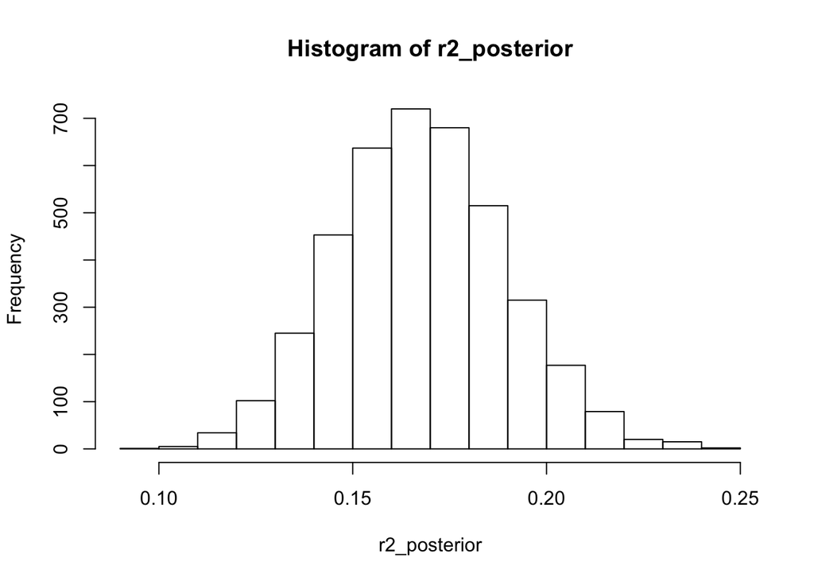

```r
# Calculate the posterior distribution of the R-squared
r2_posterior <- bayes_R2(stan_model)

# Make a histogram of the distribution
hist(r2_posterior)
```

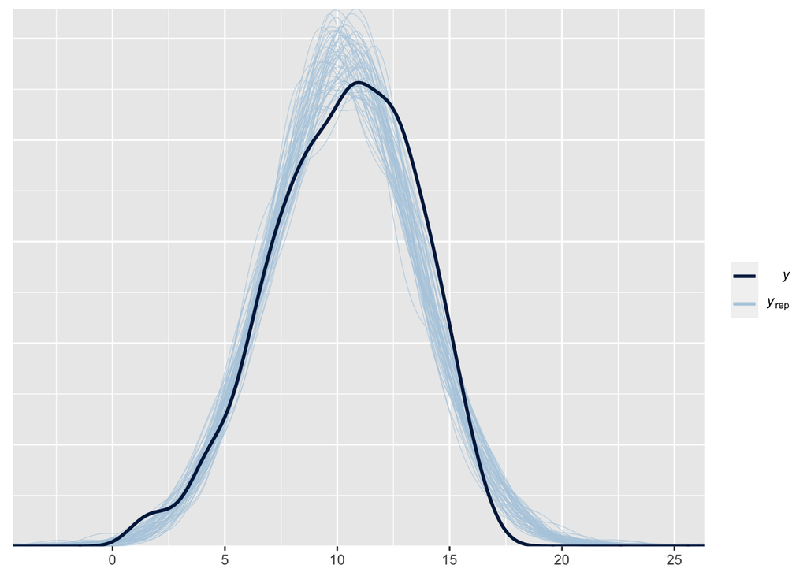

```r
# Create density comparison
pp_check(stan_model, "dens_overlay")
```

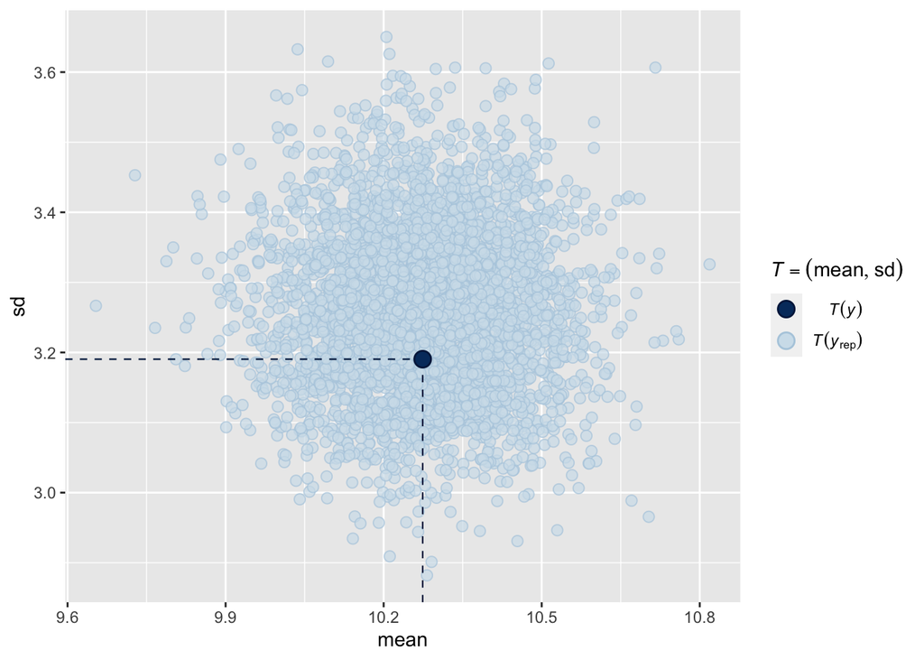

```r
# Create scatter plot of means and standard deviations
pp_check(stan_model, "stat_2d")
```